# Ethylene AF calcs

16/03/26

26/02/26

Retesting on Stimpy `epsproc-dev` docker container.

UPDATES:

- Fails for local code, version `/home/jovyan/github/epsproc`.
- Set to use `code-share` version, `(base) jovyan@1fccb2085fdb:~/code-share/github-share/ePSproc$ pip install -e . --user` (note this fails with perms issues without `--user`).
- This includes updates from March 2025, when last messing about with alignment stuff and updates, but some of these didn't make it to the GH version yet.

17/02/25

CO2 with ADMs from VM 07/01/25

Working from N2O notebook, https://phockett.github.io/ePSdata/N2O-preliminary/N2O_AF_basicPlots_120624.html

Updates:

- Updated ADM class for text file case.
  - Ran with `wignerDpoly` norm... get results, but quite a lot of singularities/large values, suggesting renorm issue? Tested thres=1e-5, 1e-6 and not much change.
  - Ran with `wignerDlinear` norm... looks a bit better, suggesting renorm issue? Tested thres=1e-6 and not much change.
  - Ran with `sph` norm... very small beta params on average, B00 in 6 to 8 ish range, but get smoother results and no singularities.
  - Hmmm, go with `sph` for now, although need to confirm values - maybe still have issues here...

12/06/24

- Rerun for trange=[17,23]
- Use updated HV plotting routines.

22/03/24

Alignment frame calcs preliminary:

- Load and plot alignment data (ADMs) for all temperatures.
- Compute AF results for given temp (with t downsampling), note default case assumes linear pol, $z$-axis alignment.
- Plot XS and betas, interactive heatmaps and line plots.

**Note all plots are interactive, mouse-over for data points, and use toolbars for zoom/selection, and widgets for browsing data types (where applicable).**

For general methods: https://epsproc.readthedocs.io/en/dev/demos/ePSproc_class_demo_161020.html

```python
# Quick hack to override default HTML template
# NOT required in some JLab versions.
# https://stackoverflow.com/a/63777508
# https://stackoverflow.com/questions/21971449/how-do-i-increase-the-cell-width-of-the-jupyter-ipython-notebook-in-my-browser
from IPython.core.display import display, HTML
display(HTML("<style>.container { width:100% !important; }</style>"))
```

```python
%load_ext autoreload
%autoreload 2
```

## Load alignment data

Now with ADM class.

```python
from epsproc.classes.alignment import ADM
from pathlib import Path

# dataPath = Path('~/ePS/N2O/alignment/Wigner D polyatomic normalized')
# dataPath = Path('~/jake-home/ePS/N2O/alignment/Wigner D polyatomic normalized')
# dataPath = Path('~/jake-home/projects-share/woodhouse_minns_collabs_2023/co2_eli_2024/CO2_ADMs_070125')
# dataPath = Path('/home/jovyan/work/co2_eli_2024/CO2_ADMs_070125')  # Data dir Stimpy/Docker Feb 2026, CO2

# dataPath = Path('/home/jovyan/work/eli_woodhouse_AFPADs_2026/C2H4_ADMs_8TW_120fs_VM')  # Old ADMs circa 2021
# dataPath = Path('/home/jovyan/work/eli_woodhouse_AFPADs_2026/c2h4_ADMs_VM_160326/ADMs/10K_8TW_300fs')  # ADMs 16/03/26, 10K case
dataPath = Path('/home/jovyan/work/eli_woodhouse_AFPADs_2026/c2h4_ADMs_VM_160326/ADMs/5K_8TW_300fs')  # ADMs 16/03/26, 5K case
# ADMtype = '.mat'
ADMtype = '.dat'

# - Ran with `wignerDpoly` norm... get results, but quite a lot of singularities/large values, suggesting renorm issue? Tested thres=1e-5, 1e-6 and not much change.
# - Ran with `wignerDlinear` norm... looks better, suggesting renorm issue? Tested thres=1e-6 and not much change.
# - Ran with 'sph' norm... very small beta params on average, B00 in 6 to 8 ish range, but get smoother results and no singularities.
# Hmmm, go with sph for now, although need to confirm values - maybe still have issues here...
normType='sph'

ADMin = ADM(fileBase=dataPath.expanduser(), ext = ADMtype)

ADMin.loadData(keyType='fileName', normType=normType, matFileKey='Atemp')  #, addQ = True)
# dataTest, pdTest, e = ADMin.loadData(keyType='fileName', normType=normType, matFileKey='Atemp')  #, addQ = True)
# ADMin.loadData(keyType='T')
# ADMin.loadData(keyType='setADMsT')
# ADMin.loadData(keyType='setADMsT', addS=False, addPop=False)
```

```
OMP: Info #273: omp_set_nested routine deprecated, please use omp_set_max_active_levels instead.
```

```
* sparse not found, sparse matrix forms not available.
* natsort not found, some sorting functions not available.
```

```
* Setting plotter defaults with epsproc.basicPlotters.setPlotters(). Run directly to modify, or change options in local env.
* Set Holoviews with bokeh.
* pyevtk not found, VTK export not available.
Scanning /home/jovyan/work/eli_woodhouse_AFPADs_2026/c2h4_ADMs_VM_160326/ADMs/5K_8TW_300fs for ePS jobs.
Found ePS output files in root dir /home/jovyan/work/eli_woodhouse_AFPADs_2026/c2h4_ADMs_VM_160326/ADMs/5K_8TW_300fs.

*** Scanning dir
/home/jovyan/work/eli_woodhouse_AFPADs_2026/c2h4_ADMs_VM_160326/ADMs/5K_8TW_300fs
Found 14 .dat file(s)

Set self.norm from self.norms['sph'].
Found t-index /home/jovyan/work/eli_woodhouse_AFPADs_2026/c2h4_ADMs_VM_160326/ADMs/time.mat
Failed to read t-index /home/jovyan/work/eli_woodhouse_AFPADs_2026/c2h4_ADMs_VM_160326/ADMs/time.mat, setting tIndex=None.
*** Attempting to sort text files assuming one file per ADM...
Getting t-axis from file C2H4_5K_ELI I=8TW tau=300fs D20.dat. Set `tAxisInFile=False` to bypass.
Got 1102 time points.
[[2 0]
 [2 2]
 [4 0]
 [4 2]
 [4 4]
 [6 0]
 [6 2]
 [6 4]
 [6 6]
 [8 0]
 [8 2]
 [8 4]
 [8 6]
 [8 8]]
Setting ADMs using index [[0. 0.]
 [2. 0.]
 [2. 2.]
 [4. 0.]
 [4. 2.]
 [4. 4.]
 [6. 0.]
 [6. 2.]
 [6. 4.]
 [6. 6.]
 [8. 0.]
 [8. 2.]
 [8. 4.]
 [8. 6.]
 [8. 8.]].
Files from self.fileDict read OK, outputs: self.dataDict and self.data.
```

```python
# pdTest['C2H4_10K_ELI I=8TW tau=300fs D20'][2]
```

```python
ADMin.fileList
```

```
[['/home/jovyan/work/eli_woodhouse_AFPADs_2026/c2h4_ADMs_VM_160326/ADMs/5K_8TW_300fs/C2H4_5K_ELI I=8TW tau=300fs D20.dat',
  '/home/jovyan/work/eli_woodhouse_AFPADs_2026/c2h4_ADMs_VM_160326/ADMs/5K_8TW_300fs/C2H4_5K_ELI I=8TW tau=300fs D22.dat',
  '/home/jovyan/work/eli_woodhouse_AFPADs_2026/c2h4_ADMs_VM_160326/ADMs/5K_8TW_300fs/C2H4_5K_ELI I=8TW tau=300fs D40.dat',
  '/home/jovyan/work/eli_woodhouse_AFPADs_2026/c2h4_ADMs_VM_160326/ADMs/5K_8TW_300fs/C2H4_5K_ELI I=8TW tau=300fs D42.dat',
  '/home/jovyan/work/eli_woodhouse_AFPADs_2026/c2h4_ADMs_VM_160326/ADMs/5K_8TW_300fs/C2H4_5K_ELI I=8TW tau=300fs D44.dat',
  '/home/jovyan/work/eli_woodhouse_AFPADs_2026/c2h4_ADMs_VM_160326/ADMs/5K_8TW_300fs/C2H4_5K_ELI I=8TW tau=300fs D60.dat',
  '/home/jovyan/work/eli_woodhouse_AFPADs_2026/c2h4_ADMs_VM_160326/ADMs/5K_8TW_300fs/C2H4_5K_ELI I=8TW tau=300fs D62.dat',
  '/home/jovyan/work/eli_woodhouse_AFPADs_2026/c2h4_ADMs_VM_160326/ADMs/5K_8TW_300fs/C2H4_5K_ELI I=8TW tau=300fs D64.dat',
  '/home/jovyan/work/eli_woodhouse_AFPADs_2026/c2h4_ADMs_VM_160326/ADMs/5K_8TW_300fs/C2H4_5K_ELI I=8TW tau=300fs D66.dat',
  '/home/jovyan/work/eli_woodhouse_AFPADs_2026/c2h4_ADMs_VM_160326/ADMs/5K_8TW_300fs/C2H4_5K_ELI I=8TW tau=300fs D80.dat',
  '/home/jovyan/work/eli_woodhouse_AFPADs_2026/c2h4_ADMs_VM_160326/ADMs/5K_8TW_300fs/C2H4_5K_ELI I=8TW tau=300fs D82.dat',
  '/home/jovyan/work/eli_woodhouse_AFPADs_2026/c2h4_ADMs_VM_160326/ADMs/5K_8TW_300fs/C2H4_5K_ELI I=8TW tau=300fs D84.dat',
  '/home/jovyan/work/eli_woodhouse_AFPADs_2026/c2h4_ADMs_VM_160326/ADMs/5K_8TW_300fs/C2H4_5K_ELI I=8TW tau=300fs D86.dat',
  '/home/jovyan/work/eli_woodhouse_AFPADs_2026/c2h4_ADMs_VM_160326/ADMs/5K_8TW_300fs/C2H4_5K_ELI I=8TW tau=300fs D88.dat']]
```

```python
# dir(e)
# print(f"{type(e).__name__} at line {e.__traceback__.tb_lineno} of : {e}")
```

```python
# dataTest
```

```python
# ADMin.data['CO2_ADMs_070125']['ADM']
```

```python
# import epsproc as ep

# ep.setADMs

ADMin.plot(width=1000)
# ADMin.plot(xlim=(30,50), width=800)  # Auto-stack plus pass args & zoom in on specific region (note slider will reset region with interactive zoom)
```

[interactive chart not shown]

```python
# ADMin.dataDict
```

## Load matrix elements

```python
# Plotters
# from epsproc.plot import hvPlotters

# Multijob class dev code
from epsproc.classes.multiJob import ePSmultiJob

# import warnings
# # warnings.filterwarnings('once')   # Skip repeated numpy deprecation warnings in current build (xr15 env)
# warnings.filterwarnings('ignore')   # Skip repeated numpy deprecation warnings in current build (xr15 env)
```

```python
# # Scan for subdirs, based on existing routine in getFiles()

# fileBase = Path('/home/paul/ePS/OCS/OCS_survey')  # Data dir on Stimpy

# fileBase = Path('~/fock-mount/globalhome/eps/N2O/N2O_valence').expanduser() # Data dir on Jake

# fileBase = Path('/home/jovyan/jake-home/femtobackSSHFS/FemtoShare/Results/ePolyScat_stuff/co2') # Data dir on Jake via Docker QM3 container

# fileBase = Path('/home/jovyan/work/co2_eli_2024/CO2_ePS_2019')  # Data dir Stimpy/Docker Feb 2026

# fileBase = Path('/home/jovyan/work/co2_eli_2024/CO2_ePS_2019')  # Data dir Stimpy/Docker Feb 2026, CO2
fileBase = Path('/home/jovyan/work/eli_woodhouse_AFPADs_2026/eps/c2h4_1-30eV') # Data dir Stimpy/Docker Feb 2026, ethylene
```

```python
# TODO: fix orb label here, currently relies on (different) fixed format

data = ePSmultiJob(fileBase, verbose = 0, ext='.inp.out', jobStructure='subDirs')  # TODO: fix subDirs usage!
                                                                                    # CO2 case: fix by setting .inp.out, otherwise also reads base dir (older results)

data.scanFiles(outputKeyType='orb')
data.jobsSummary()
```

```
Found 1 directories, with 3 files.

*** Job orb6 details
Key: orb6
Dir /home/jovyan/work/eli_woodhouse_AFPADs_2026/eps/c2h4_1-30eV, 1 file(s).
{   'batch': 'ePS ethylene, batch C2H4_1.0-30.0eV, orbital orb6_Ag',
    'event': 'HOMO-2 ioinzation (Ag), wavefn run, 0.5:1:10.5, sph grid',
    'orbE': -16.065602439631316,
    'orbLabel': 'orb6',
    'symmetryLabel': 'Ag'}

*** Job orb7 details
Key: orb7
Dir /home/jovyan/work/eli_woodhouse_AFPADs_2026/eps/c2h4_1-30eV, 1 file(s).
{   'batch': 'ePS ethylene, batch C2H4_1.0-30.0eV, orbital orb7_B3g',
    'event': 'HOMO-1 ioinzation (B3g), wavefn run, 0.5:1:10.5, sph grid',
    'orbE': -13.755355747346933,
    'orbLabel': 'orb7',
    'symmetryLabel': 'B3g'}

*** Job orb8 details
Key: orb8
Dir /home/jovyan/work/eli_woodhouse_AFPADs_2026/eps/c2h4_1-30eV, 1 file(s).
{   'batch': 'ePS ethylene, batch C2H4_1.0-30.0eV, orbital orb8_B3u',
    'event': 'HOMO ioinzation (B3u), wavefn run, 0.5:1:10.5, sph grid',
    'orbE': -10.32127880310325,
    'orbLabel': 'orb8',
    'symmetryLabel': 'B3u'}

*** Job stacked details
Key: stacked
No 'job' info set for self.data[stacked].
```

```
*** Molecular structure
```

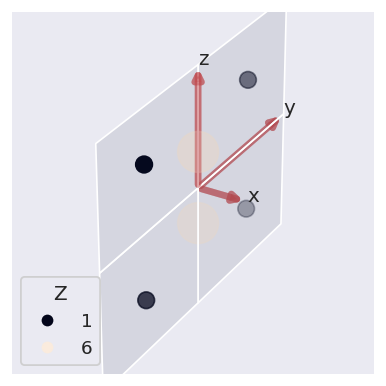

```
*** Molecular orbital list (from ePS output file)
EH = Energy (Hartrees), E = Energy (eV), NOrbGrp, OrbGrp, GrpDegen = degeneracies and corresponding orbital numbering by group in ePS, NormInt = single centre expansion convergence (should be ~1.0).
```

| props orb | Sym | EH | Occ | E | NOrbGrp | OrbGrp | GrpDegen | NormInt |
| --- | --- | --- | --- | --- | --- | --- | --- | --- |
| 1 | AG | -11.2385 | 2.0 | -305.815164 | 1.0 | 1.0 | 1.0 | 0.999386 |
| 2 | B1U | -11.2367 | 2.0 | -305.766184 | 1.0 | 2.0 | 1.0 | 0.999287 |
| 3 | AG | -1.0395 | 2.0 | -28.286236 | 1.0 | 3.0 | 1.0 | 0.999968 |
| 4 | B1U | -0.7933 | 2.0 | -21.586793 | 1.0 | 4.0 | 1.0 | 0.999983 |
| 5 | B2U | -0.6450 | 2.0 | -17.551344 | 1.0 | 5.0 | 1.0 | 0.999997 |
| 6 | AG | -0.5904 | 2.0 | -16.065602 | 1.0 | 6.0 | 1.0 | 0.999998 |
| 7 | B3G | -0.5055 | 2.0 | -13.755356 | 1.0 | 7.0 | 1.0 | 0.999995 |
| 8 | B3U | -0.3793 | 2.0 | -10.321279 | 1.0 | 8.0 | 1.0 | 1.000002 |

```python
# data.jobs

data.molSummary()
```

```python
data.data.keys()
```

```
dict_keys(['orb6', 'orb7', 'orb8', 'stacked'])
```

```python
# TODO!
# Fix labels for plots

# # Set state labels
# v = ['C','B','A','X']
# sDict = {n:v[k] for k,n in enumerate(range(9,13))}

# for key in data.data.keys():
#     data.data[key]['jobNotes']['orbKey'] = key  # Existing orb key, from filename
#     data.data[key]['jobNotes']['orbGroup'] = int(key.strip('orb')) + 1   # Corrected orb group
# #     data.data[key]['jobNotes']['orbLabel'] = f"HOMO - {12 - int(key.strip('orb')) - 1}"
#     data.data[key]['jobNotes']['orbLabel'] = sDict[data.data[key]['jobNotes']['orbGroup']]
```

## Compute AF

Note default case assumes linear pol, $z$-axis alignment.

```python
# Set ADMs to use for calc - set for specific T and downsample

# Subselection, note temperature is set by dataKey here
# temp = '10K'
admKey = dataPath.name   # For dir case
# trange = [25,40]   # For CO2
# tStep = 8

# trange = [200, 350]  # For ethylene no tIndex
# trange = [18, 20]  # For ethylene, with tIndex - don't see huge changes with t in this case?
# trange = [37, 40]  # Later revival structure
trange = [10,13] # Earlier revival structure
tStep = 6

# ADMin.subsetADMs(dataKey = temp, trange=[35,45],tStep = 5)
ADMin.subsetADMs(dataKey = admKey, trange=trange,tStep = tStep)

# Plot subselection
ADMin.plot(keys='ADM')

# Set to main data structure for calcs
data.data['ADM'] = ADMin.data['ADM']
```

```
Setting subset data from `self.data['5K_8TW_300fs']['ADM']`
Selecting 11 points
Set subset data to `self.data['ADM']['ADM']`
```

[interactive chart not shown]

```python
# Basic routine (no grouping)
import epsproc as ep
thres = 1e-3  # For ethylene hitting RAM issues with thres<1e-3
# data.AFBLM(AKQS = data.data['ADM']['ADM'].real, selDims = {'Type':'L'}, thres=1e-2) # OK for 41 t-points (x2 downsample), but missing some orbs and t-points in output!
# data.AFBLM(AKQS = data.data['ADM']['ADM'].real, selDims = {'Type':'L'}, thres=thres) # OK for 41 t-points (x2 downsample), still some missing regions for thres=1e-2
                                                                                       # mostly contiguous for thres = 1e-3,1e-4
data.AFBLM(AKQS = data.data['ADM']['ADM'].real, selDims = {'Type':'L'}, thres=thres)   # outputs fairly smooth for thres=1e-5

# # Save full class with Pickle
# # TODO: GENERAL DEBUG FOR ACCIDENTAL FUNCTION PASSING HERE!!!!
# import pickle
# temp = 'exp'
# outfile = f'CO2_AFBLM_{temp}_t{trange[0]}-{trange[1]}_{thres}_180225.pickle'
# with open(outfile, 'wb') as handle:
# #     data.data['ADM']['plots']['ADM']['pData'].attrs['pTypeDetails'] = []  # UGH, this breaks pickle unless removed.
#     pickle.dump(data.data, handle, protocol=pickle.HIGHEST_PROTOCOL)
#     print(f'Saved data.data with pickle, file: {outfile}')

#     # Also save to HDF5 (AFBLM only)
#     for orb in data.data.keys():
#         # Skip non-orb keys
#         # if orb.startswith('orb'):
#         if orb.startswith('co2'):
#             ep.IO.writeXarray(data.data[orb]['AFBLM'], fileName=f'CO2_AFBLM_{orb}_{temp}_t{trange[0]}-{trange[1]}_{thres}_180225.h5', engine='hdf5')
```

```python
# # Load data from previous runs...
# thres = 1e-5
# # infile = f'N2O_AFBLM_{temp}_{thres}_220323.pickle'
# # infile = 'N2O_AFBLM_10K_0.0001_220323.pickle'
# # infile = 'N2O_AFBLM_10K_1e-05_220323.pickle'
# infile = f'N2O_AFBLM_{temp}_t{trange[0]}-{trange[1]}_{thres}_120624.pickle'

# import pickle
# with open(infile, 'rb') as handle:
#     dataIn = pickle.load(handle)

# data.data = dataIn
```

## Plots

Remarks:

- Some unphysical spikes in values <5eV, these are regions with small cross-sections, and are currently filtered out in these plots.
- General patterns seem to be simlar to R-matrix results, as expected, although absolute Blm values seem larger...? Might be a normalisation difference here, TBC.

### Cross-sections & AF-$\beta_{L,M}$ heatmaps

NOTE: interactive plots. Roll over plots for values and tool options. For heatmaps use the "box select" tool on the histogram at the side to change the colour mapping scale (and zooming on histogram should also give more detail).

```python
# v2 with pkg code...
# from epsproc.plot import hvPlotters
# hvPlotters.setPlotDefaults(fSize = [700,300], imgSize = 600)
data.BLMplot(backend='hv', xDim = 't', hvType='heatmap', addHist = True, addADMs = False, XS=True,
             # selDims={'L':[2,4,6]},
             # Etype = 'Ehv',
             # clim=(-0.5,0.5), cmap='vlag', width=1000, frame_width=860, filterXS=1e-3)  # Large plot
              cmap='vlag', width=400, frame_width=400, filterXS=1e-3)  # Small size for layout later
```

```
BLMplot set data and plots to self.plots['BLMplot']
```

[output not shown]

[interactive chart not shown]

```
True
```

```python
data.plots['BLMplot']['hv'].select(l=0,m=0, Orb=['orb7','orb8']).layout('Orb')
```

[output not shown]

[interactive chart not shown]

```python
data.plots['BLMplot']['hv'].select(l=[2,4,6],m=0, Orb=['orb7','orb8']).opts(clim=(-0.1,0.6)).layout(['Orb','l']).cols(3)   # .select(l=[2,4,6],
```

[output not shown]

[interactive chart not shown]

### AFPADs

Selected by orb, Eke and t.

```python
# data.verbose['main']=True
# data.padPlot(keys='orb8_S', dataType='AFBLM',Etype='t', squeeze=True, selDims={'Eke':[5.1],'t':data.data['orb8_S']['AFBLM'].t[slice(20,50,5)]},
#              width = 1400, height = 800, backend='pl')
```

```python
# AFPADs at selected (E,t)
# data.verbose['main']=True
# data.padPlot(keys='orb8_S', dataType='AFBLM',Etype='t', squeeze=True, selDims={'Eke':[5.1],'t':data.data['orb8_S']['AFBLM'].t[slice(20,50,2)]},
#              width = 1400, height = 1200, backend='pl')
```

```python
# Phi-summed PADs vs. t (single Eke)
# data.padPlot(dataType='AFBLM',Etype='t', squeeze=False, selDims={'Eke':[5.1]},   # selDims={'t':data.data['orb8_S']['AFBLM'].t[slice(20,50,2)]},
#              width = 1400, height = 500, reducePhi='sum', pStyle='grid', backend='hv')  #, hvClims=0.5,)  # facetDims=['Eke',None])  #, hvClims=None, hvCHist=False)   #facetDims=['Labels', 'Eke'])  #, backend='pl', reducePhi='sum')
```

```python
# Phi-summed PADs vs. t (single Eke), global cmap
# data.padPlot(dataType='AFBLM',Etype='t', squeeze=False, selDims={'Eke':[5.1]},   # selDims={'t':data.data['orb8_S']['AFBLM'].t[slice(20,50,2)]},
#              width = 1400, height = 500, reducePhi='sum', pStyle='grid', backend='hv', clim=(0,30), hvCHist=False)
```

### AF-$\beta_{L,M}$ line-outs

Results as above, line-outs per (orb,Eke) with interactive browser widget.

```python
data.data.keys()
```

```
dict_keys(['orb6', 'orb7', 'orb8', 'stacked', 'ADM'])
```

```python
data.jobKeys
```

```
['orb6', 'orb7', 'orb8']
```

```python
# data.data['c2h4_1-30eV']
# data.data['stacked']
```

```python
# Line-outs
# Note this is quite slow to render
data.BLMplot(backend='hv', hvType='line', xDim = 't', ylim=(-1,2), filterXS=1e-3, thres=1e-5, XS = True,
             addADMs = False, height=800, width=1000)

# For Ehv case can't plot all at once, so set panels per orb/job

# for k in data.jobKeys:
#     data.BLMplot(backend='hv', hvType='line', xDim = 't', # ylim=(-0.5,1), filterXS=1e-3,
#                  # Etype = 'Ehv',
#                  keys = k,
#                  addADMs = False, height=800, width=1000, title = f"{k}, norm={normType}, thres={thres}")
```

```
BLMplot set data and plots to self.plots['BLMplot']
```

[interactive chart not shown]

```
True
```

```python
data.plots['BLMplot']['hv'].select(l=[0]).overlay('Eke').layout('Orb')  #.opts(width=1000).cols(1)
```

[interactive chart not shown]

### AF + expt

```python
# Read from XLSX file
import pandas as pd

# Original data April 2024
# df = pd.read_excel('~/jake-home/projects-share/woodhouse_minns_collabs_2023/co2_eli_2024/exp_results_april_2024/CO2_scan_betas.xlsx').set_index('Delay')

# Data with B6 Feb 2025
df = pd.read_excel('~/jake-home/projects-share/woodhouse_minns_collabs_2023/co2_eli_2024/CO2_exp_results_Feb_2025/CO2_scan_betas.xlsx').set_index('Delay')

# Resort to state, L indexing...

newCols = pd.MultiIndex.from_product([['E','X'],[2,4,6]])  # str for HV plot

# for item df.columns.to_list():

df = df.reindex(sorted(df.columns), axis=1)
df.columns = newCols

# Plot - recall issues with Multiindex and hvplot... should be ok with HV directly?
import hvplot.pandas

dfPlot = df['X']
# dfPlot.columns = dfPlot.columns.to_flat_index()
expPlot = dfPlot.hvplot(height=400, width=1000)
```

[output not shown]

[output cut: 11 more lines]

[output not shown]

```python
k = 'co2_1pg_0.1-50.1eV'
data.BLMplot(backend='hv', hvType='line', xDim = 't', # ylim=(-0.5,1), filterXS=1e-3,
             # Etype = 'Ehv',
             keys = k,
             addADMs = False, height=400, width=1000, title = f"{k}, norm={normType}, thres={thres}",
             renderPlot = False)


(data.plots['BLMplot']['hv'].select(Eke=11.1).select(l=[2,4,6]).overlay('l').opts(width=1000) + expPlot).cols(1)
```

[output not shown]

```python
data.plots['BLMplot'].keys()
```

```python
df['X']
```

## Versions

### Code

```python
# print(data.jobInfo['ePolyScat'][0])
# print('Run: ' + jobInfo['Starting'][0].split('at')[1])
```

```python
import scooby
scooby.Report(additional=['epsproc', 'xarray', 'jupyter', 'holoviews', 'pandas'])
```

```python
# Check current Git commit for local ePSproc version
import epsproc as ep
!git -C {Path(ep.__file__).parent} branch
!git -C {Path(ep.__file__).parent} log --format="%H" -n 1
```

```python
# Check current remote commits
!git ls-remote --heads https://github.com/phockett/ePSproc
```

```python
import epsproc as ep
ep.__file__
```

### Notes

22/03/24

v1, quick run based on [previous OCS code](https://phockett.github.io/ePSdata/OCS-preliminary/OCS_orbs8-11_AFBLMs_VM-ADMs_140122-JAKE_tidy-replot-200722_v5.html) plus a few recent function updates.

TODO:

- Testing with alternative polarization states.
- More careful tests/checks in low-XS regions (currently just filter out, but see BLM spikes in a few cases without XS filter applied).
- More careful comparison with R-matrix results.
- AF-PAD plots, grids should work here...

## Scratch

```python
break
```

```python
# Compute AFBLMs for aligned case
keys = data._keysCheck(None)
keys = list(set(keys) - set(['ADM']))


#*************** Throw everything in method - breaks for large datasets (RAM issues)
# data.AFBLM(keys = keys, AKQS = ADMs, selDims = {'Type':'L'})  # NOTE THIS USES independently set ADMs!

# data.AFBLM(keys = keys, AKQS = data.data['ADM']['ADM'].real, selDims = {'Type':'L'}, thres=1e-3) # OK for 61 t-points (x2 downsample)
# data.AFBLM(keys = keys, AKQS = data.data['ADM']['ADM'].real, selDims = {'Type':'L'}, thres=1e-3, thresDims = ['Eke','t'])   # NEED TO ADD DIM CHECKING TO thresDims
# data.AFBLM(keys = keys, AKQS = data.data['ADM']['ADM'].real, selDims = {'Type':'L'}, thres=1e-4)   # 1e-4 working OK for 30 t-points (x4 downsample)
# data.AFBLM(keys = keys, AKQS = data.data['ADM']['ADM'].real, selDims = {'Type':'L'}, thres=1e-5)   # 1e-5 working OK for 16 t-points (x8 downsample)
# data.AFBLM(keys = keys, AKQS = data.data['ADM']['ADM'].real, selDims = {'Type':'L'}, thres=1e-6)   # 1e-6 working OK for 16 t-points (x8 downsample)
# data.AFBLM(keys = keys, AKQS = data.data['ADM']['ADM'].real, selDims = {'Type':'L'}, thres=None)   # FAILS for 16 t-points (x8 downsample) at 60Gb RAM on Jake (Swap file size issue????)
                                                                                                   # OK for 8 t-points (x16 downsample) at ~55Gb RAM peak on Jake.
# thres=1e-4)  BREAKS KERNEL #, thresDims=['Eke','t'])  # TODO: currently thersDims must be in matE only for AFBLM routine.

# 21/07/22 version - above only gives L=2 max, missing L=4,6. But bumping threshold to 1e-4 kills calculation...
# data.AFBLM(keys = keys,  selDims = {'Type':'L'})  # Default case... sets/uses ADMs per key
# UPDATE: testing with scale factor for ADMs, and forcing to real - might be better?


#*********** Using grouping to avoid memory issues
#        QUITE slow with current code, but more robust
#        TODO: make this better with basis set recycle (cf. fitting code)
#
import pickle

def calcAFBLMGroup(data,ADMs,keys,AFBLMdict):
    """Wrap for XR groupby"""

    # Class routine - returns to main datastruture
    data.AFBLM(keys = keys, AKQS = ADMs, selDims = {'Type':'L'}, thres=None)  #.map(standardize)

    # Copy to new structure & restack
#     keys = data._keysCheck(keys)

#     AFBLMdict = {}
    # Restack data to lists for merge
    for key in keys:
        AFBLMdict[key]['AFBLMlist'].append(data.data[key]['AFBLM'].copy())

    return AFBLMdict


AFBLMdict = {k:{'AFBLMlist':[]} for k in keys}

# tBins = np.arange(38,39.1,0.5)   # Test range
tBins = np.arange(trange[0], trange[1] + 0.1, 0.5)
# trange

import time

for item in data.data['ADM']['ADM'].groupby_bins("t", tBins):
    start = time.time()
    print(f'Calculating for group: {item[0]}, {item[1].t.size} t-points.')
    AFBLMdict = calcAFBLMGroup(data, item[1], keys, AFBLMdict)
    end = time.time()
    print(f'Delta: {end - start}s')

# Concat XR lists
for key in keys:
    AFBLMdict[key]['full'] = xr.concat(AFBLMdict[key]['AFBLMlist'],"t")
    AFBLMdict[key]['full'].name = f'{key}_AFBLM'

    # Push back to main class
    data.data[key]['AFBLM'] = AFBLMdict[key]['full'].copy()

    # Save object with Pickle
    with open(f'OCS_{key}_AFBLM_220722.pickle', 'wb') as handle:
        print(f'Saving {key} with pickle')
        pickle.dump(AFBLMdict[key]['full'], handle, protocol=pickle.HIGHEST_PROTOCOL)

# Save full class with Pickle
# NOW GIVING ERRORS ON RERUN (although worked previously), AttributeError: Can't pickle local object 'plotTypeSelector.<locals>.<lambda>'
# NOT SURE WHERE THIS IS COMING FROM AS YET
# UPDATE: IN data.data['ADM']['plots']['ADM']['pData'].attrs['pTypeDetails']
# TODO: GENERAL DEBUG FOR ACCIDENTAL FUNCTION PASSING HERE!!!!
# import pickle
with open(f'OCS_AFBLM_220722.pickle', 'wb') as handle:
    data.data['ADM']['plots']['ADM']['pData'].attrs['pTypeDetails'] = []  # UGH, this breaks pickle unless removed.
    pickle.dump(data, handle, protocol=pickle.HIGHEST_PROTOCOL)
    print(f'Saved data (full class) with pickle')
```